# Zusammenfassung der ersten Ergebnisse

Simulation Phylogenetic Decisivness

Janne Pott

20.03.2022

# 1 Intro

Was habe ich simuliert?

1. Vorbereitungen:
   - alle möglichen Quadrupel für n=6, 7, und 8 erstellt
   - alle möglichen 4-way-partitions für n=6, 7, und 8 erstellt
2. Schleife pro k (Anzahl Input-Quadrupels)
3. Simulation mit 10,000 Wiederholungen, d.h. 10,000 mal ein zufälliges Set aus k Quadrupeln erstellt und getestet, ob phylogenetisch entscheidend nach 4WPP und nach Fischers Algorithmus (Wahrheit vs Vorhersage)
4. Alle Simulationsergebnisse sind lokal gespeichert, die Zusammenfassung auch auf github abgelegt.

Jetzt: Zusammenfassung der Vorhersagegüte erstellen. Dazu will ich ein paar Barplots erstellen (Anzahl phylogenetisch entscheidender Sets gemäß 4WPP und Algorithmus). Zusätzlich will ich für die Testgüte die Parameter der 4-Feldertafeln ausrechnen (negative predictive value, power).

Ich will die Auswertung einmal über alle k machen und einmal ab meinem Schrankenwert aus der MA:

Upper border: Ab einer Quadrupelanzahl größer oder gleich $\binom{n}{4} - (n-4)$ sind alle Sets phylogenetisch entscheidend.

- n=6: 15-2 = 13
- n=7: 35-3 = 32
- n=8: 70-4 = 66

Lower border: Keine einfache Formel für alle n. Ich nutze hier die Anzahl mit der alle Triple mindestens einmal abgedeckt sind. Siehe MA S. 9

- n=6: 6
- n=7: 11
- n=8: 14

# 2 Init

```r
rm(list = ls())
time0<-Sys.time()

.libPaths("C:/userprograms/R_4.1.1/")
library(data.table)
library(ggplot2)
library(foreach)

source("../helperFunctions/my4FTFunction.R")

x6_lb = 6
x6_ub = 13
x7_lb = 11
x7_ub = 32
x8_lb = 14
x8_ub = 66
```

# 3 Get data

n=6, n=7, und n=8

```r
load("../results/SimulationResults_n6.RData")
load("../results/SimulationResults_n7.RData")
load("../results/SimulationResults_n8.RData")

sim_n6 = SimulationResults_n6[k>=x6_lb & k<=x6_ub]
sim_n7 = SimulationResults_n7[k>=x7_lb & k<=x7_ub]
sim_n8 = SimulationResults_n8[k>=x8_lb & k<=x8_ub]
```

# 4 Bar plots

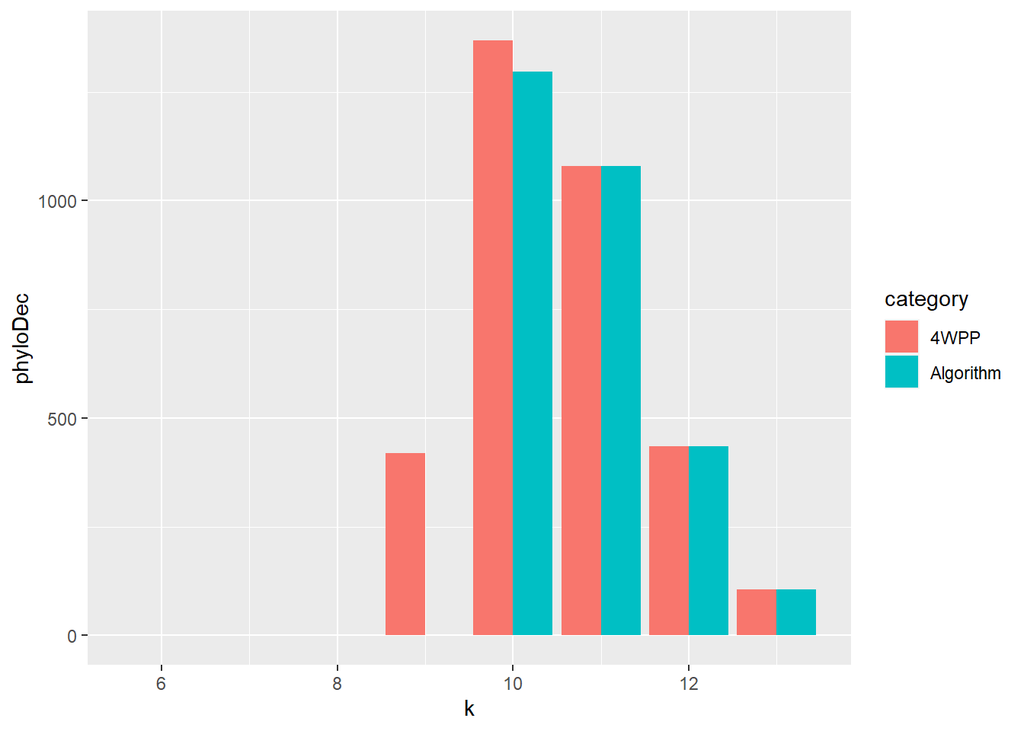

```r
x6 = dim(sim_n6)[1]
PlotData_n6 = data.table(k = rep(sim_n6$k,2),
                         phyloDec = c(sim_n6$NR_FAlg_pos,
                                      sim_n6$NR_PhyloDec),
                         category = c(rep("Algorithm",x6),rep("4WPP",x6)))
ggplot(data=PlotData_n6,aes(fill=category, y=phyloDec, x=k)) +
  geom_bar(position="dodge", stat="identity")
```

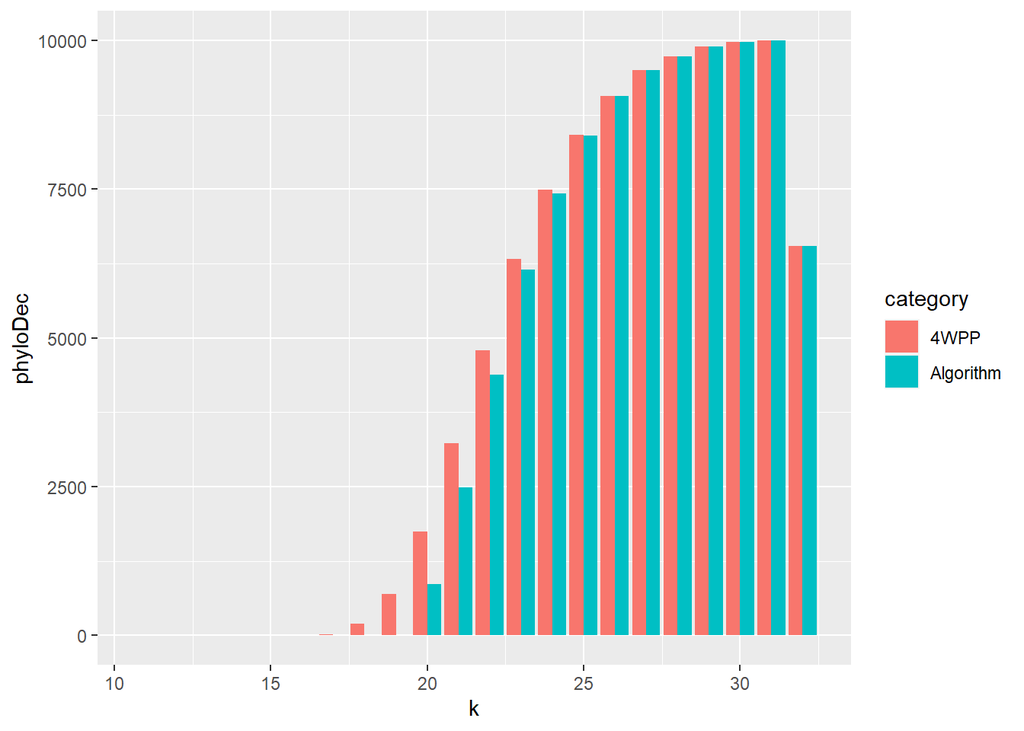

```r
x7 = dim(sim_n7)[1]
PlotData_n7 = data.table(k = rep(sim_n7$k,2),
                         phyloDec = c(sim_n7$NR_FAlg_pos,
                                      sim_n7$NR_PhyloDec),
                         category = c(rep("Algorithm",x7),rep("4WPP",x7)))
ggplot(data=PlotData_n7,aes(fill=category, y=phyloDec, x=k)) +
  geom_bar(position="dodge", stat="identity")
```

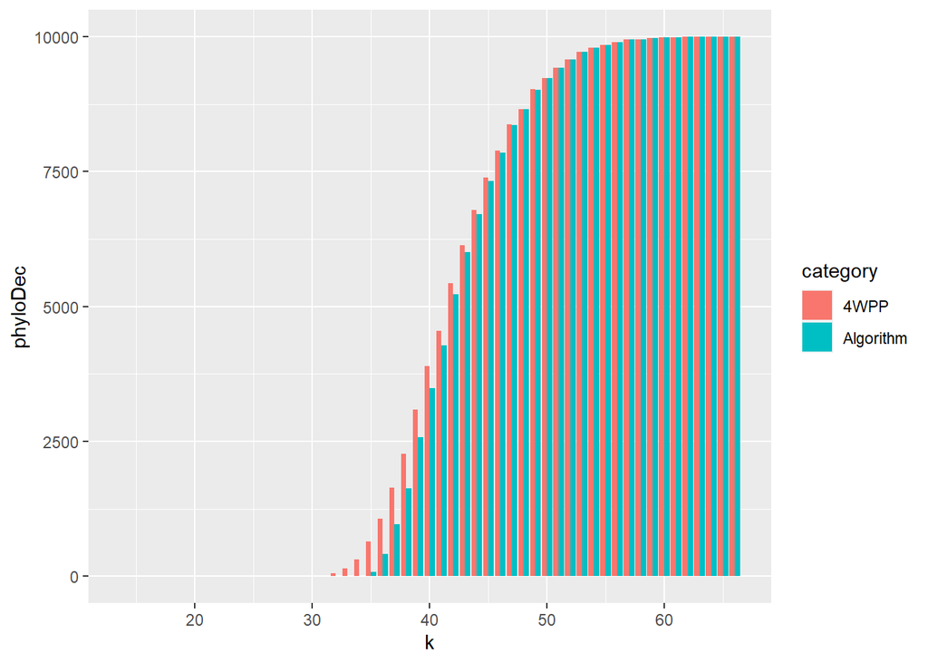

```r
x8 = dim(sim_n8)[1]
PlotData_n8 = data.table(k = rep(sim_n8$k,2),
                         phyloDec = c(sim_n8$NR_FAlg_pos,
                                      sim_n8$NR_PhyloDec),
                         category = c(rep("Algorithm",x8),rep("4WPP",x8)))
ggplot(data=PlotData_n8, aes(fill=category, y=phyloDec, x=k)) +
  geom_bar(position="dodge", stat="identity")
```

# 5 Scatter plots

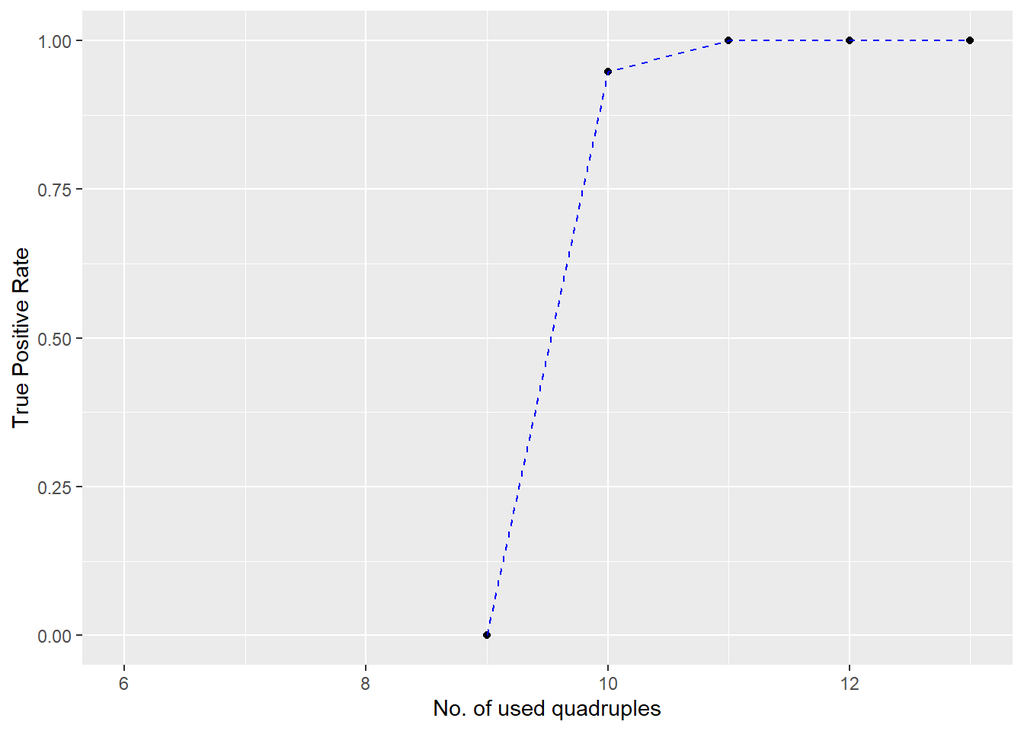

```r
ggplot(sim_n6,aes(x=k,y=posRate)) +
  geom_point() +
  geom_line(linetype = "dashed", color = "blue") +
  scale_x_continuous('No. of used quadruples') +
  scale_y_continuous ('True Positive Rate')
```

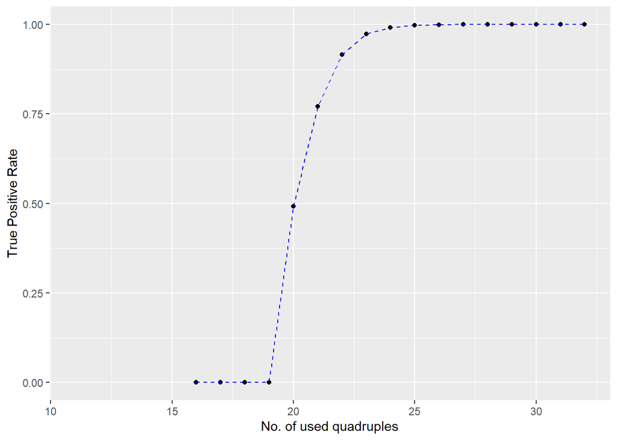

```r
ggplot(sim_n7,aes(x=k,y=posRate)) +
  geom_point() +
  geom_line(linetype = "dashed", color = "blue") +
  scale_x_continuous('No. of used quadruples') +
  scale_y_continuous ('True Positive Rate')
```

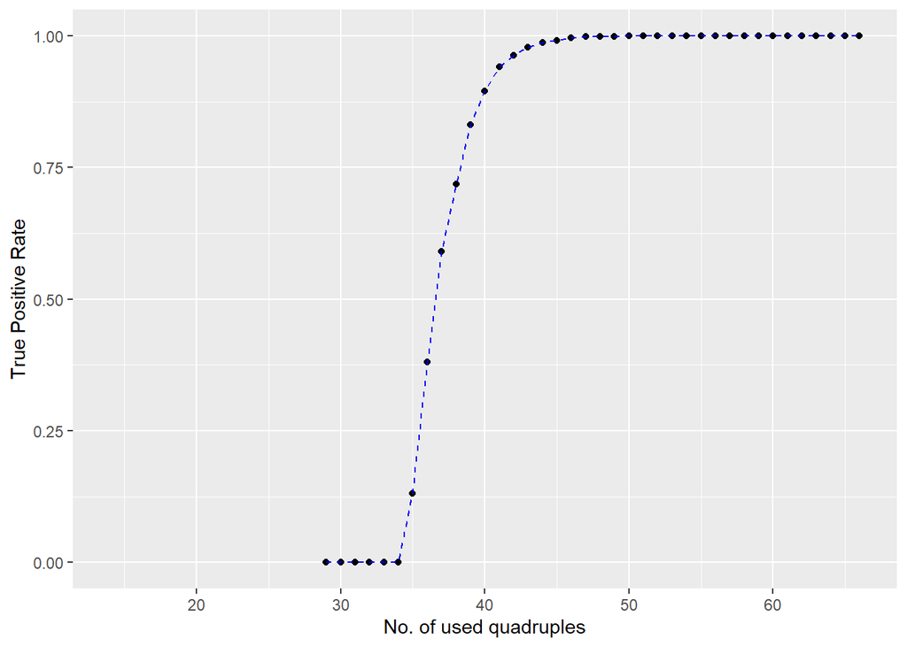

```r
ggplot(sim_n8,aes(x=k,y=posRate)) +
  geom_point() +
  geom_line(linetype = "dashed", color = "blue") +
  scale_x_continuous('No. of used quadruples') +
  scale_y_continuous ('True Positive Rate')
```

# 6 Vier-Feldertafel

- Prevalence = actual positive (P) / all (N+P)
- PPV = Positive Predictive Value = true positives (TP) / predicted positives (PP)
- NPV = Negative Predictive Value = true negatives (TN) / predicted negatives = bedingte Wahrscheinlichkeit P(wahrer Zustand negativ | Prädiktion negativ)
- TPR = True Positive Rate = sensitivity = power = TP / P
- TNR = True Negative Rate = specificity = TN / N
- see also [Wikipedia](https://en.wikipedia.org/wiki/Positive_and_negative_predictive_values)

```r
stats_n6 = my4FTFunction(P = sum(SimulationResults_n6$NR_PhyloDec),
                         N = sum(SimulationResults_n6$NR_NotPhyloDec),
                         PP = sum(SimulationResults_n6$NR_FAlg_pos))
stats_n7 = my4FTFunction(P = sum(SimulationResults_n7$NR_PhyloDec),
                         N = sum(SimulationResults_n7$NR_NotPhyloDec),
                         PP = sum(SimulationResults_n7$NR_FAlg_pos))
stats_n8 = my4FTFunction(P = sum(SimulationResults_n8$NR_PhyloDec),
                         N = sum(SimulationResults_n8$NR_NotPhyloDec),
                         PP = sum(SimulationResults_n8$NR_FAlg_pos))
stats = rbind(stats_n6,stats_n7,stats_n8)
stats
```

```
##    Prevalence PPV       NPV       TPR TNR
## 1:  0.1044680   1 0.9835093 0.8562664   1
## 2:  0.3337353   1 0.9840043 0.9675472   1
## 3:  0.3927584   1 0.9880900 0.9813641   1
```

```r
stats_n6 = my4FTFunction(P = sum(sim_n6$NR_PhyloDec),
                         N = sum(sim_n6$NR_NotPhyloDec),
                         PP = sum(sim_n6$NR_FAlg_pos))
stats_n7 = my4FTFunction(P = sum(sim_n7$NR_PhyloDec),
                         N = sum(sim_n7$NR_NotPhyloDec),
                         PP = sum(sim_n7$NR_FAlg_pos))
stats_n8 = my4FTFunction(P = sum(sim_n8$NR_PhyloDec),
                         N = sum(sim_n8$NR_NotPhyloDec),
                         PP = sum(sim_n8$NR_FAlg_pos))
stats2 = rbind(stats_n6,stats_n7,stats_n8)
stats2
```

```
##    Prevalence PPV       NPV       TPR TNR
## 1:  0.1225547   1 0.9802346 0.8556338   1
## 2:  0.4507377   1 0.9738962 0.9673377   1
## 3:  0.4618113   1 0.9834709 0.9804135   1
```

**Fazit 1**: NPV ist in der Simulation relativ konstant bei 98%, d.h. mit 98%-iger Wahrscheinlichkeit ist ein negatives Set auch wirklich nicht phylogentisch entscheidend.

**Fazit 2**: Die Gesamt-Power nimmt zu.

Was passiert, wenn man das pro k macht?

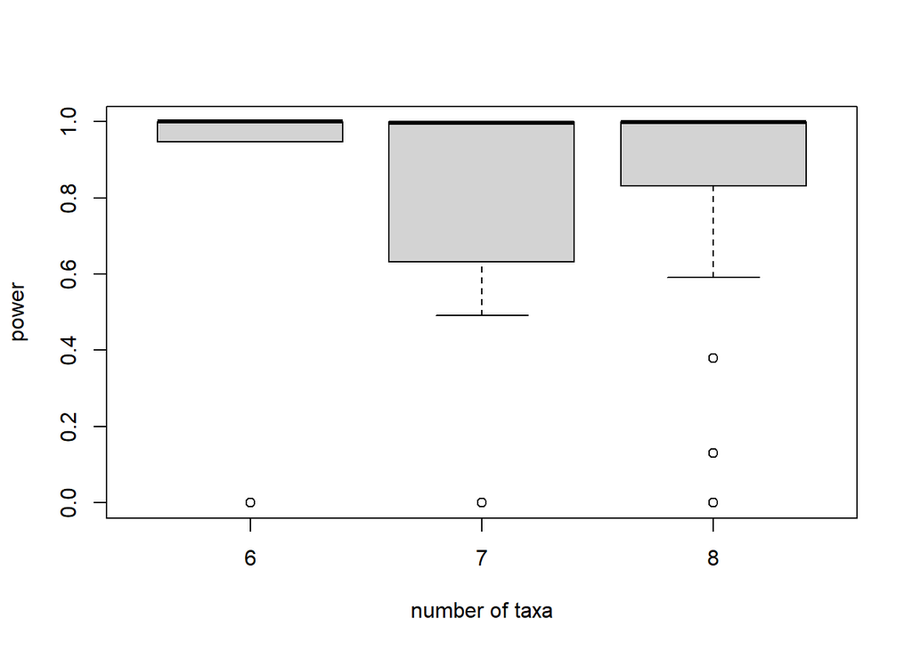

```r
dumTab = foreach(i = 1:dim(SimulationResults_n6)[1])%do%{
  #i=1
  stats_k = my4FTFunction(P = SimulationResults_n6$NR_PhyloDec[i],
                        N = SimulationResults_n6$NR_NotPhyloDec[i],
                        PP = SimulationResults_n6$NR_FAlg_pos[i])
  stats_k[,n :=6]
  stats_k[,k := i]
  stats_k[,status := "bad"]
  if(i>=x6_lb & i<= x6_ub)stats_k[,status := "good"]
  stats_k

}
stats_n6_byk = rbindlist(dumTab)

dumTab = foreach(i = 1:dim(SimulationResults_n7)[1])%do%{
  #i=1
  stats_k = my4FTFunction(P = SimulationResults_n7$NR_PhyloDec[i],
                        N = SimulationResults_n7$NR_NotPhyloDec[i],
                        PP = SimulationResults_n7$NR_FAlg_pos[i])
  stats_k[,n :=7]
  stats_k[,k := i]
  stats_k[,status := "bad"]
  if(i>=x7_lb & i<= x7_ub)stats_k[,status := "good"]
  stats_k

}
stats_n7_byk = rbindlist(dumTab)

dumTab = foreach(i = 1:dim(SimulationResults_n8)[1])%do%{
  #i=1
  stats_k = my4FTFunction(P = SimulationResults_n8$NR_PhyloDec[i],
                        N = SimulationResults_n8$NR_NotPhyloDec[i],
                        PP = SimulationResults_n8$NR_FAlg_pos[i])
  stats_k[,n :=8]
  stats_k[,k := i]
  stats_k[,status := "bad"]
  if(i>=x8_lb & i<= x8_ub)stats_k[,status := "good"]
  stats_k

}
stats_n8_byk = rbindlist(dumTab)

stats_byk = rbind(stats_n6_byk,stats_n7_byk,stats_n8_byk)

boxplot(stats_byk$TPR ~ stats_byk$n,
        xlab = "number of taxa",
        ylab = "power")
```

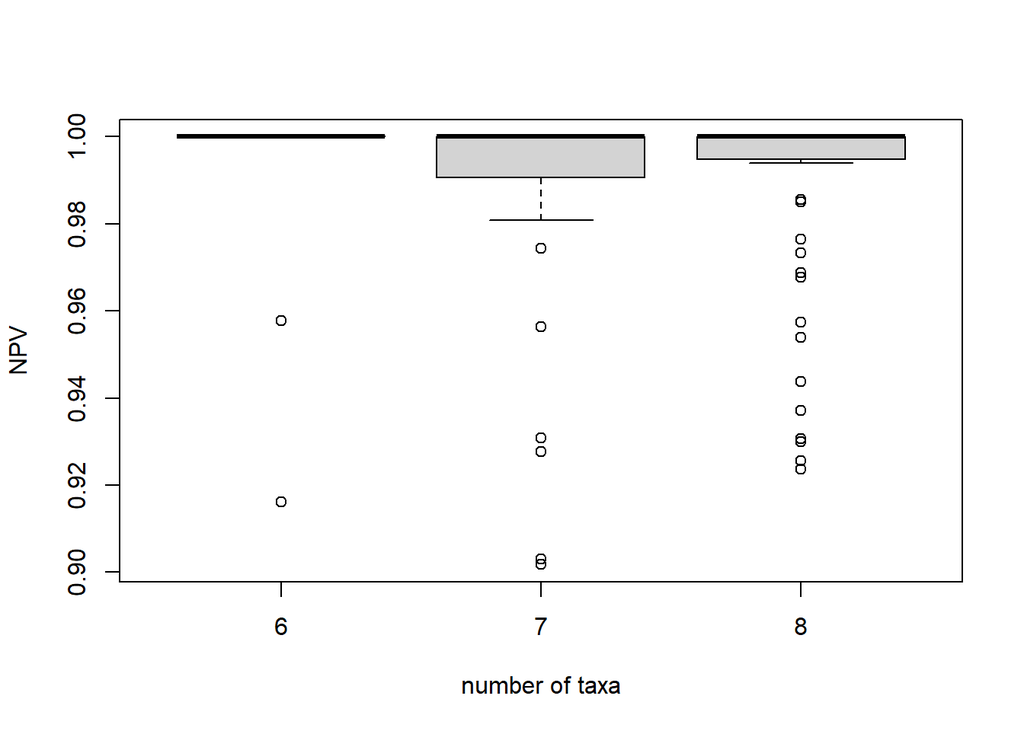

```r
boxplot(stats_byk$NPV ~ stats_byk$n,
        xlab = "number of taxa",
        ylab = "NPV")
```

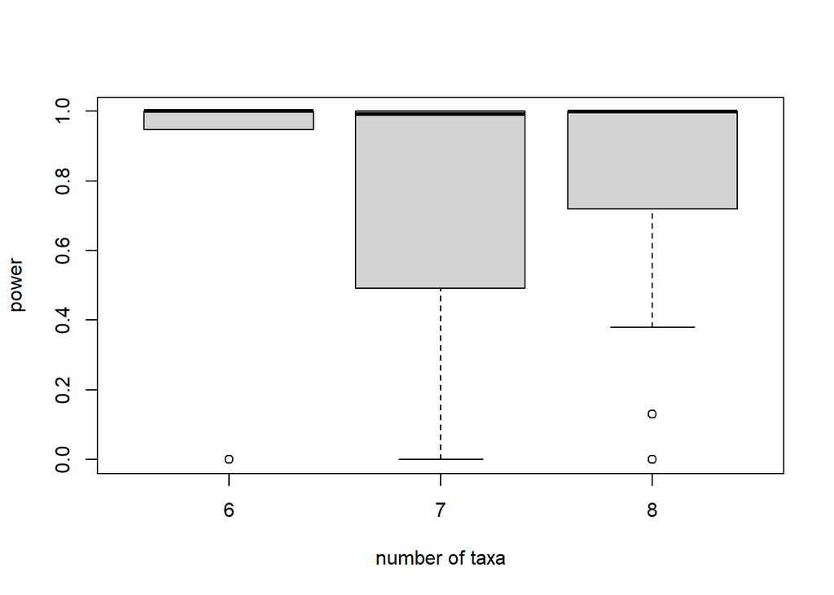

```r
filt = stats_byk$status =="good"
boxplot(stats_byk$TPR[filt] ~ stats_byk$n[filt],
        xlab = "number of taxa",
        ylab = "power")
```

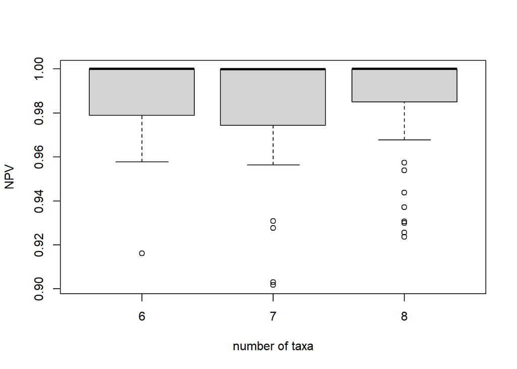

```r
boxplot(stats_byk$NPV[filt] ~ stats_byk$n[filt],
        xlab = "number of taxa",
        ylab = "NPV")
```

```r
tab6 = stats_byk[n==6,summary(TPR)]
tab7 = stats_byk[n==7,summary(TPR)]
tab8 = stats_byk[n==8,summary(TPR)]
tab_TPR1 = rbind(tab6,tab7,tab8)
tab6 = stats_byk[n==6 & filt,summary(TPR)]
tab7 = stats_byk[n==7 & filt,summary(TPR)]
tab8 = stats_byk[n==8 & filt,summary(TPR)]
tab_TPR2 = rbind(tab6,tab7,tab8)

tab6_NPV = stats_byk[n==6,summary(NPV)]
tab7_NPV = stats_byk[n==7,summary(NPV)]
tab8_NPV = stats_byk[n==8,summary(NPV)]
tab_NPV1 = rbind(tab6_NPV,tab7_NPV,tab8_NPV)
tab6_NPV = stats_byk[n==6 & filt,summary(NPV)]
tab7_NPV = stats_byk[n==7 & filt,summary(NPV)]
tab8_NPV = stats_byk[n==8 & filt,summary(NPV)]
tab_NPV2 = rbind(tab6_NPV,tab7_NPV,tab8_NPV)

tabs = rbind(tab_NPV1,tab_NPV2,tab_TPR1,tab_TPR2)
rownames(tabs) = c("NPV_n6","NPV_n7","NPV_n8",
                   "NPV_n6_filtered","NPV_n7_filtered","NPV_n8_filtered",
                   "TPR_n6","TPR_n7","TPR_n8",
                   "TPR_n6_filtered","TPR_n7_filtered","TPR_n8_filtered")
tabs
```

```
##                      Min.   1st Qu.    Median      Mean 3rd Qu. Max. NA's
## NPV_n6          0.9160839 1.0000000 1.0000000 0.9894921       1    1    2
## NPV_n7          0.9017833 0.9906612 1.0000000 0.9856338       1    1    3
## NPV_n8          0.9236103 0.9948324 1.0000000 0.9892469       1    1    7
## NPV_n6_filtered 0.9160839 0.9789104 1.0000000 0.9819864       1    1    1
## NPV_n7_filtered 0.9017833 0.9743390 0.9999000 0.9787928       1    1    1
## NPV_n8_filtered 0.9236103 0.9850677 1.0000000 0.9863941       1    1    4
## TPR_n6          0.0000000 0.9605263 1.0000000 0.8245614       1    1    8
## TPR_n7          0.0000000 0.6316821 0.9978605 0.7442258       1    1   15
## TPR_n8          0.0000000 0.8318784 0.9994459 0.7903180       1    1   28
## TPR_n6_filtered 0.0000000 0.9473684 1.0000000 0.7894737       1    1    3
## TPR_n7_filtered 0.0000000 0.4922725 0.9911930 0.7141347       1    1    5
## TPR_n8_filtered 0.0000000 0.7472176 0.9991182 0.7737641       1    1   15
```

```r
message("\nTOTAL TIME : " ,round(difftime(Sys.time(),time0,units = "mins"),3)," minutes")
```

```
##
## TOTAL TIME : 0.047 minutes
```